# 2016 Burnham & Lehman Queen Experirment

P. Alexander Burnham

September 14, 2016

**Metadata:**

**Author:** P. Alexander Burnham

**Date:** 10 August 2016

**Data Set:** These data were collected in 2016 in New York state by Andre Burnham and the Hamilton College bee research team from two yards in NY owned by one beekeeper who volunteered for the study.

**Data Source:** 2016 Hamilton Bee Research Project

**Funding Source:** Hamilton College undergraduate research grants

**Data Collection:** Weights of colonies were obtained by summing the weights of individual hive bodies and supers for each colony at each yard (add more about protocols for other assays).

**Missing values:** NA

```r
#Preliminaries:

ls()
```

```
## character(0)
```

```r
rm(list=ls())

# Set Working Directory
setwd("~/Desktop/QueenExperimentBurnham")

# read in data for all three .csv files:
QueensDF <- read.table("2016QueensHam.csv",header=TRUE,sep=",",stringsAsFactors=FALSE)

VirusDF <- read.table("RNAVirus.csv",header=TRUE,sep=",",stringsAsFactors=FALSE)

PollenDF <- read.table("PollenQueens.csv",header=TRUE,sep=",",stringsAsFactors=FALSE)
```

```r
# looking at colony mass through time

#subsetting by removing rows that have missing data:
QueensMassDF <- QueensDF[-c(95,98,102,104,105),]

# create summary and sd and se using plyr
library(plyr)
MassSummary <- ddply(QueensMassDF, c("Origin", "Time"), summarise,
                  n = length(Mass),
                  mean = mean(Mass),
                  sd = sd(Mass),
                  se = sd / sqrt(n))

print(MassSummary)
```

```
##       Origin Time  n     mean        sd       se
## 1 California   T1 20 23.43000  5.096655 1.139647
## 2 California   T2 16 27.86250  8.960571 2.240143
## 3 California   T3  9 39.93333 15.427573 5.142524
## 4 California   T4  9 40.68889 17.132750 5.710917
## 5      Local   T1 20 25.21000  4.309341 0.963598
## 6      Local   T2 19 38.14737 12.422711 2.849965
## 7      Local   T3 17 43.77647 15.910355 3.858828
## 8      Local   T4 17 57.87059 21.473465 5.208080
```

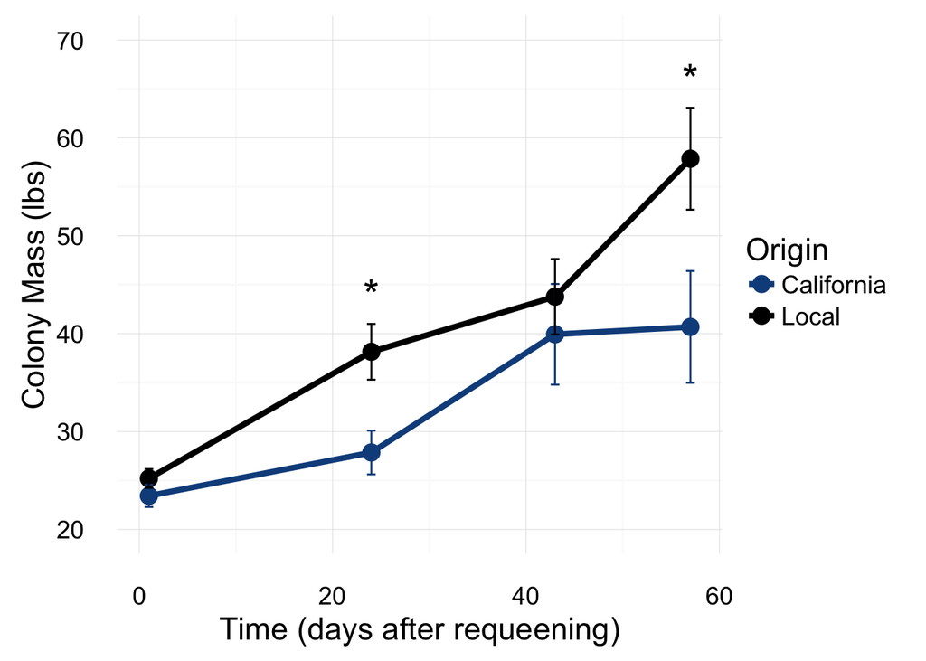

```r
library(ggplot2)

# remove generic time steps and add the correct days for correct time scale
x <- MassSummary[,-2]
times <- c(1,24,43,57,1,24,43,57)
x <- data.frame(times, x)

#Create plot in ggplot
plot <- ggplot(data = x,
               aes(x = times,
                   y = mean,
                   group = Origin,
                   colour = Origin)
               ) + geom_line(size=1.5) + geom_point(size=4) + scale_colour_manual(values = c("dodgerblue4", "black")) + labs(x = "Time (days after requeening)", y = "Colony Mass (lbs)") + coord_cartesian(ylim = c(20, 70)) + geom_errorbar(aes(ymin = mean - se, ymax = mean + se, width = 0.9))

# add a theme and add asterix for significance
plot + scale_fill_brewer(palette = "Paired") + theme_minimal(base_size = 17) + annotate(geom = "text", x = 24, y = 44, label = "*",cex = 8) + annotate(geom = "text", x = 57, y = 66, label = "*",cex = 8)
```

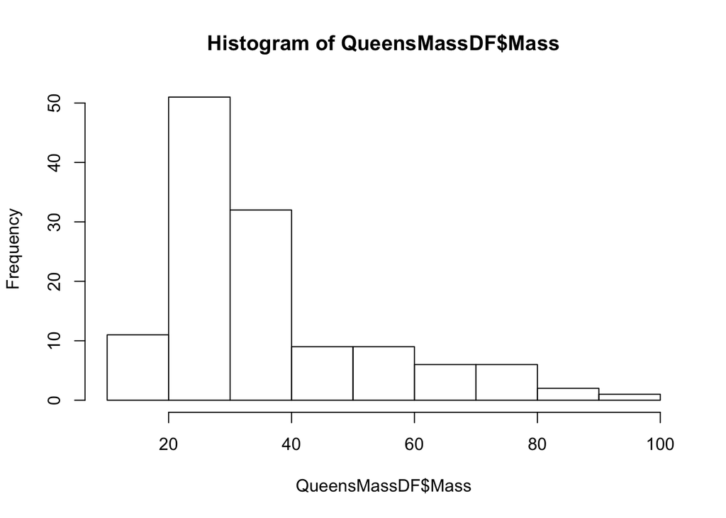

```r
#Check for normality and log transform
hist(QueensMassDF$Mass)
```

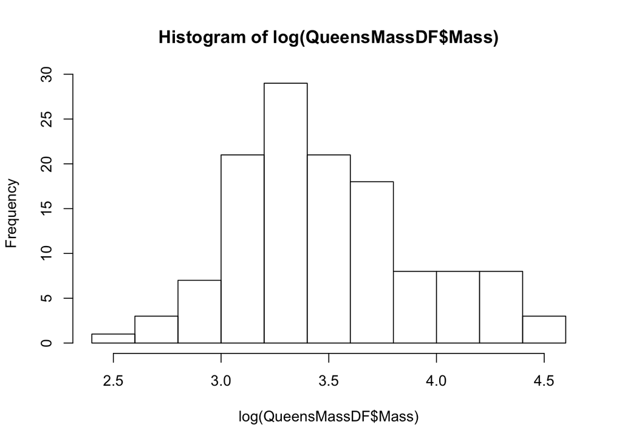

```r
hist(log(QueensMassDF$Mass))
```

```r
#Subset data into 4 time steps (T1-T4)
QMassT1 <- QueensMassDF[c(1:40),]
QMassT2 <- QueensMassDF[c(41:75),]
QMassT3 <- QueensMassDF[c(76:106),]
QMassT4 <- QueensMassDF[c(107:132),]

# run 4 t-tests comparing california to local colony mass
ComparingQueensMassT1 <- aov(log(Mass)~Origin, data=QMassT1)
ComparingQueensMassT2 <- aov(log(Mass)~Origin, data=QMassT2)
ComparingQueensMassT3 <- aov(log(Mass)~Origin, data=QMassT3)
ComparingQueensMassT4 <- aov(log(Mass)~Origin, data=QMassT4)

# view the summary of the stats:
summary(ComparingQueensMassT1)
```

```
##             Df Sum Sq Mean Sq F value Pr(>F)
## Origin       1 0.0713 0.07132   1.731  0.196
## Residuals   38 1.5656 0.04120
```

```r
summary(ComparingQueensMassT2)
```

```
##             Df Sum Sq Mean Sq F value  Pr(>F)
## Origin       1  0.880  0.8804   8.124 0.00747 **
## Residuals   33  3.576  0.1084
## ---
## Signif. codes:  0 '***' 0.001 '**' 0.01 '*' 0.05 '.' 0.1 ' ' 1
```

```r
summary(ComparingQueensMassT3)
```

```
##             Df Sum Sq Mean Sq F value Pr(>F)
## Origin       1  0.063 0.06296   0.498  0.486
## Residuals   29  3.663 0.12632
```

```r
summary(ComparingQueensMassT4)
```

```
##             Df Sum Sq Mean Sq F value Pr(>F)
## Origin       1 0.9836  0.9836   6.831 0.0171 *
## Residuals   19 2.7359  0.1440
## ---
## Signif. codes:  0 '***' 0.001 '**' 0.01 '*' 0.05 '.' 0.1 ' ' 1
## 5 observations deleted due to missingness
```

```r
#subsetting by removing rows that have missing data:
QueensNosemaDF <- QueensDF[-c(35,(41:75)),]

times <- c(rep("T1",39),rep("T2",31),rep("T3",26))

QueensNosemaDF <- data.frame(QueensNosemaDF, times)

# create summary and sd and se using plyr
library(plyr)
NosemaSummary <- ddply(QueensNosemaDF, c("Origin", "NosemaDay"), summarise,
                     n = length(Nosema),
                     mean = mean(Nosema),
                     sd = sd(Nosema),
                     se = sd / sqrt(n))

print(NosemaSummary)
```

```
##       Origin NosemaDay  n      mean        sd       se
## 1 California         1 19 1268421.1 1643079.8 376948.4
## 2 California        34 14 3292857.1 3327340.5 889269.2
## 3 California        55  9 2200000.0  923901.4 307967.1
## 4      Local         1 20 1665000.0 2225530.7 497643.8
## 5      Local        34 17  851470.6 1146546.1 278078.3
## 6      Local        55 17  325000.0  637806.3 154690.7
```